# LRGD_NBA

## Linear Regression with Gradient Descent on NBA Player Data (2018-19)

The goal here is to use linear regression with gradient descent to predict relationships between different player variables. First, I want to look at the relationship between salary and points per game.

## Loading in Data, isolating variables

```python
import pandas
import numpy as np
import matplotlib.pyplot as plt
```

```python
nba = pandas.read_csv('nbastats2018-2019.csv')
nba
```

|  | Name | Height | Weight | Team | Age | Salary | Points | Blocks | Steals | Assists | ... | MP | G | PER | OWS | DWS | WS | WS48 | USG | BPM | VORP |
| --- | --- | --- | --- | --- | --- | --- | --- | --- | --- | --- | --- | --- | --- | --- | --- | --- | --- | --- | --- | --- | --- |
| 0 | Alex Abrines | 78 | 200 | Oklahoma City Thunder | 25 | 5455236 | 5.3 | 0.2 | 0.5 | 0.6 | ... | 19.0 | 31 | 6.3 | 0.1 | 0.6 | 0.6 | 0.053 | 12.2 | -3.4 | -0.2 |
| 1 | Quincy Acy | 79 | 240 | Phoenix Suns | 28 | 213949 | 1.7 | 0.4 | 0.1 | 0.8 | ... | 12.3 | 10 | 2.9 | -0.1 | 0.0 | -0.1 | -0.022 | 9.2 | -5.9 | -0.1 |
| 2 | Jaylen Adams | 74 | 190 | Atlanta Hawks | 22 | 236854 | 3.2 | 0.1 | 0.4 | 1.9 | ... | 12.6 | 34 | 7.6 | -0.1 | 0.2 | 0.1 | 0.011 | 13.5 | -4.4 | -0.3 |
| 3 | Steven Adams | 84 | 265 | Oklahoma City Thunder | 25 | 24157304 | 13.9 | 1.0 | 1.5 | 1.6 | ... | 33.4 | 80 | 18.5 | 5.1 | 4.0 | 9.1 | 0.163 | 16.4 | 2.7 | 3.2 |
| 4 | Bam Adebayo | 82 | 255 | Miami Heat | 21 | 2955840 | 8.9 | 0.8 | 0.9 | 2.2 | ... | 23.3 | 82 | 17.9 | 3.4 | 3.4 | 6.8 | 0.171 | 15.8 | 3.0 | 2.4 |
| ... | ... | ... | ... | ... | ... | ... | ... | ... | ... | ... | ... | ... | ... | ... | ... | ... | ... | ... | ... | ... | ... |
| 516 | Trae Young | 74 | 180 | Atlanta Hawks | 20 | 5356440 | 19.1 | 0.2 | 0.9 | 8.1 | ... | 30.9 | 81 | 17.0 | 2.5 | 0.7 | 3.3 | 0.062 | 28.4 | -1.1 | 0.6 |
| 517 | Cody Zeller | 84 | 240 | Charlotte Hornets | 26 | 13528090 | 10.1 | 0.8 | 0.8 | 2.1 | ... | 25.4 | 49 | 17.2 | 2.6 | 1.2 | 3.9 | 0.150 | 16.3 | 2.0 | 1.2 |
| 518 | Tyler Zeller | 84 | 253 | Atlanta Hawks | 29 | 106974 | 7.7 | 0.5 | 0.2 | 0.7 | ... | 15.5 | 6 | 17.3 | 0.2 | 0.1 | 0.3 | 0.167 | 20.1 | -2.2 | 0.0 |
| 519 | Ante Zizic | 83 | 254 | Cleveland Cavaliers | 22 | 1952760 | 7.8 | 0.4 | 0.2 | 0.9 | ... | 18.3 | 59 | 16.2 | 1.7 | 0.3 | 2.0 | 0.087 | 18.2 | -3.1 | -0.3 |
| 520 | Ivica Zubac | 85 | 240 | Los Angeles Clippers | 21 | 1544951 | 8.9 | 0.9 | 0.2 | 1.1 | ... | 17.6 | 59 | 18.9 | 1.9 | 1.3 | 3.2 | 0.148 | 20.3 | -0.3 | 0.5 |

521 rows × 27 columns

## Finding meaningful relations

We want to look for a relation between two variables that has a somewhat linear trend, so that our fit can be decently accurate.

#### First we try Salary vs PPG.

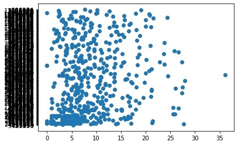

```python
ppg = np.array(nba['Points'])
salary = np.array(nba['Salary'])
plt.scatter(ppg, salary)
```

#### Not great! What about MPG vs PPG?

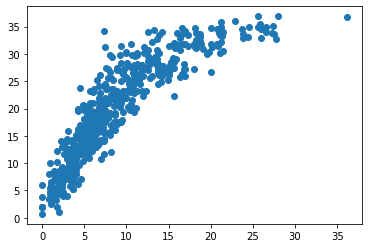

```python
ppg = np.array(nba['Points'])
minutes = np.array(nba['MP'])
plt.scatter(ppg, minutes)
```

#### Better...Might work on a range from 5 to 30 minutes. We can look for something better, though.

#### How about ppg and PER?

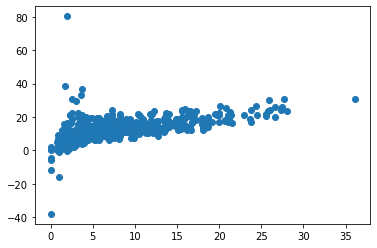

```python
ppg = np.array(nba['Points'])
PER = np.array(nba['PER'])
plt.scatter(ppg, PER)
```

#### This will work! Not perfect, but viable

Hold on though....

Let's talk about PER. It's Player Efficieny Rating, and is meant to encapsulate all aspects of a player's play into one stat. It's flawed, of course, and some argue it favors bigs, but it's an interesting metric nonetheless.

The highest PER of all time for a single season was set by Nikola Jokic in 2021-2022, with a PER of 32.85. We see some huge outliers on this plot though. Who recorded a PER of over 80? That seems unlikely...

Let's query with pandas

```python
nba.query('PER > 80')
```

|  | Name | Height | Weight | Team | Age | Salary | Points | Blocks | Steals | Assists | ... | MP | G | PER | OWS | DWS | WS | WS48 | USG | BPM | VORP |
| --- | --- | --- | --- | --- | --- | --- | --- | --- | --- | --- | --- | --- | --- | --- | --- | --- | --- | --- | --- | --- | --- |
| 405 | Zhou Qi | 85 | 210 | Houston Rockets | 23 | 506134 | 2.0 | 0.0 | 0.0 | 0.0 | ... | 1.0 | 1 | 80.4 | 0.0 | 0.0 | 0.0 | 1.261 | 43.4 | 9.5 | 0.0 |

1 rows × 27 columns

Zhou Qi! Who only played one game, for one minute. While impressive, that should obviously be excluded. Same for whover had a -40 PER.

To filter outliers, we'll redine the nba df to require say, 30 games played, and 10 minutes per game.

```python
nba = nba.query('MP > 10.0 and G > 30')
nba
```

|  | Name | Height | Weight | Team | Age | Salary | Points | Blocks | Steals | Assists | ... | MP | G | PER | OWS | DWS | WS | WS48 | USG | BPM | VORP |
| --- | --- | --- | --- | --- | --- | --- | --- | --- | --- | --- | --- | --- | --- | --- | --- | --- | --- | --- | --- | --- | --- |
| 0 | Alex Abrines | 78 | 200 | Oklahoma City Thunder | 25 | 5455236 | 5.3 | 0.2 | 0.5 | 0.6 | ... | 19.0 | 31 | 6.3 | 0.1 | 0.6 | 0.6 | 0.053 | 12.2 | -3.4 | -0.2 |
| 2 | Jaylen Adams | 74 | 190 | Atlanta Hawks | 22 | 236854 | 3.2 | 0.1 | 0.4 | 1.9 | ... | 12.6 | 34 | 7.6 | -0.1 | 0.2 | 0.1 | 0.011 | 13.5 | -4.4 | -0.3 |
| 3 | Steven Adams | 84 | 265 | Oklahoma City Thunder | 25 | 24157304 | 13.9 | 1.0 | 1.5 | 1.6 | ... | 33.4 | 80 | 18.5 | 5.1 | 4.0 | 9.1 | 0.163 | 16.4 | 2.7 | 3.2 |
| 4 | Bam Adebayo | 82 | 255 | Miami Heat | 21 | 2955840 | 8.9 | 0.8 | 0.9 | 2.2 | ... | 23.3 | 82 | 17.9 | 3.4 | 3.4 | 6.8 | 0.171 | 15.8 | 3.0 | 2.4 |
| 6 | LaMarcus Aldridge | 83 | 260 | San Antonio Spurs | 33 | 22347015 | 21.3 | 1.3 | 0.5 | 2.4 | ... | 33.2 | 81 | 22.9 | 6.4 | 2.9 | 9.3 | 0.167 | 26.9 | 1.6 | 2.5 |
| ... | ... | ... | ... | ... | ... | ... | ... | ... | ... | ... | ... | ... | ... | ... | ... | ... | ... | ... | ... | ... | ... |
| 515 | Thaddeus Young | 80 | 221 | Indiana Pacers | 30 | 13764045 | 12.6 | 0.4 | 1.5 | 2.5 | ... | 30.7 | 81 | 16.2 | 3.0 | 3.9 | 6.9 | 0.133 | 18.0 | 2.9 | 3.1 |
| 516 | Trae Young | 74 | 180 | Atlanta Hawks | 20 | 5356440 | 19.1 | 0.2 | 0.9 | 8.1 | ... | 30.9 | 81 | 17.0 | 2.5 | 0.7 | 3.3 | 0.062 | 28.4 | -1.1 | 0.6 |
| 517 | Cody Zeller | 84 | 240 | Charlotte Hornets | 26 | 13528090 | 10.1 | 0.8 | 0.8 | 2.1 | ... | 25.4 | 49 | 17.2 | 2.6 | 1.2 | 3.9 | 0.150 | 16.3 | 2.0 | 1.2 |
| 519 | Ante Zizic | 83 | 254 | Cleveland Cavaliers | 22 | 1952760 | 7.8 | 0.4 | 0.2 | 0.9 | ... | 18.3 | 59 | 16.2 | 1.7 | 0.3 | 2.0 | 0.087 | 18.2 | -3.1 | -0.3 |
| 520 | Ivica Zubac | 85 | 240 | Los Angeles Clippers | 21 | 1544951 | 8.9 | 0.9 | 0.2 | 1.1 | ... | 17.6 | 59 | 18.9 | 1.9 | 1.3 | 3.2 | 0.148 | 20.3 | -0.3 | 0.5 |

369 rows × 27 columns

#### Let's look at the PPG vs PER plot now

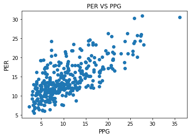

```python
ppg = np.array(nba['Points'])
PER = np.array(nba['PER'])
plt.scatter(ppg, PER)
plt.xlabel('PPG', size = 12)
plt.ylabel('PER', size = 12)
plt.title('PER VS PPG')
```

Much better! Those outliers are real MVP level players (Giannis Antetokounmpo, James Harden, Anthony Davis). Now we can get to the linear regression model!

## Implementing Linear Regression Model

Okay, so we need to define a dependent and independent variable. One of these isn't clearly dependent on the other, so it's a bit of a misnomer. But, a common argument in basketball circles is that PPG is a bad metric for judging how good a player is. PER, while very flawed, is meant to do just that.

We have seen PER correlate with PPG somewhat linearly. So, we can use a linear regression model, give it a PPG, and try to predict a player's PER.

### Defining our linear regression model

We want to use f(x) = wx + b, with w and b initially chosen at 0.

We also need to define m, the # of data points, and gamma, the learning rate, which is the scaling factor for the derivative of the error function.

Lastly, we make an array for the model prediction, fx

So we have:

w, b, m, gamma, x, y, f(x)

```python
#Initialize variables
w = 0
b = 0
m = len(ppg)
gamma = 0.001 #random initalization, will need to be adjusted
x = ppg
y = PER
fx = np.zeros(m)
```

```python
#This function will fit a line to the data given w, b, and store that in fx
def linreg(x,m,w,b):
    for i in np.arange(0,m,1):
        fx[i] = w * x[i] + b

    return fx
```

#### Finding the ideal w, b

We use the gradient descent formulation and a while loop to minimize the error function and find the best w, b

```python
def ideal_w_b(fx, m, y, gamma, w, b, wnew, bnew):

    for i in range(100000):
        sum_of_fx_minus_y = 0
        sum_of_fx_minus_y_times_x = 0
        for i in np.arange(0,m,1):
            sum_of_fx_minus_y_times_x =  sum_of_fx_minus_y_times_x + (fx[i] - y[i])*x[i]
            sum_of_fx_minus_y =  sum_of_fx_minus_y + (fx[i] - y[i])

        wnew = w - (gamma*sum_of_fx_minus_y_times_x)/m
        bnew = b - (gamma*sum_of_fx_minus_y)/m

        #implement linreg again
        fx = linreg(x,m,wnew,bnew)

        if (abs(wnew - w) < 0.00001 and abs(bnew-b) < 0.00001):
            w = wnew
            b = bnew
            return fx, w, b
            break

        w = wnew
        b = bnew
        if i == 99999:
            print('Failed to converge')
            return w, b
```

Now that we have our functions, let's run our code!

```python
wnew = 10 #placeholder vals
bnew = 10
best_fit = ideal_w_b(fx, m, y, gamma, w, b, wnew, bnew)
```

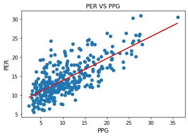

```python
ppg = np.array(nba['Points'])
PER = np.array(nba['PER'])
plt.scatter(ppg, PER)
plt.plot(ppg, best_fit[0], c = 'red')
plt.xlabel('PPG', size = 12)
plt.ylabel('PER', size = 12)
plt.title('PER VS PPG')
```

## We did it!

We have a good approximation of PER varies with PPG.

Note that the function ideal_w_b also returned the best w and b values, not just the best fit array. We can use those to predict the PER of a player given their PPG.

But we don't have to stop there. With the functions written, any 2 variables that have a linear-ish relationship can be approximated.

Let's go ahead and do some more, and drop the functions below in one cell to simplify the process.

## Further Relationships to examine

1. Points and Usage Rates

   The linear relationship is to be expected--better players have the ball more (higher usage rates) and score more points
2. Three point percentage vs Three Point Attempts

   This relationship isn't quite linear. But we'll use this to see how good we can get with our current model, and likely illustrate why more complex, non-linear models are needed for some relationships

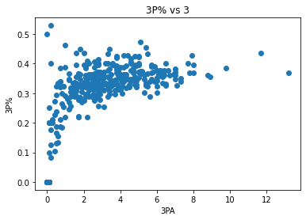

```python
FG3A = np.array(nba['FG3A'])
FG3P = np.array(nba['FG3%'])
plt.scatter(FG3A, FG3P)
plt.xlabel('3PA')
plt.ylabel('3P%')
plt.title('3P% vs 3')
```

### Note 1: We'll be using the outlier filtered nba set because we renamed it above. This is fine as the conditions for removal (games and minutes) translate well to these categories. We will need to clean up the 3 point data, as there are some NANS (for players who did not make 3s)

### Note 2: We'll need to adjust the upper limit on iterations, condition for convergence, and gamma. We can also experiment with different values

```python
#This function will fit a line to the data given w, b, and store that in fx
def linreg(x,m,w,b):
    for i in np.arange(0,m,1):
        fx[i] = w * x[i] + b

    return fx

def ideal_w_b(fx, m, y, gamma, w, b, wnew, bnew, max_iter, convergence_condition):

    for i in range(max_iter):
        sum_of_fx_minus_y = 0
        sum_of_fx_minus_y_times_x = 0
        for i in np.arange(0,m,1):
            sum_of_fx_minus_y_times_x =  sum_of_fx_minus_y_times_x + (fx[i] - y[i])*x[i]
            sum_of_fx_minus_y =  sum_of_fx_minus_y + (fx[i] - y[i])

        wnew = w - (gamma*sum_of_fx_minus_y_times_x)/m
        bnew = b - (gamma*sum_of_fx_minus_y)/m

        #implement linreg again
        fx = linreg(x,m,wnew,bnew)

        if (abs(wnew - w) < convergence_condition and abs(bnew-b) < convergence_condition):
            w = wnew
            b = bnew
            return fx, w, b
            break

        w = wnew
        b = bnew
        if i == max_iter - 1:
            print('Failed to converge')
            return w, b
```

## Usage Rate vs. Points Per Game

```python
#Initialize variables
ppg = np.array(nba['Points'])
USG = np.array(nba['USG'])

w = 0
b = 0
m = len(ppg)
gamma = 0.001 #random initalization, will need to be adjusted
x = ppg
y = USG
fx = np.zeros(m)
```

```python
wnew = 10 #placeholder vals
bnew = 10
best_fit = ideal_w_b(fx, m, y, gamma, w, b, wnew, bnew, int(1e6), 1e-6)
#Note the small range for convergence, 1e-6
```

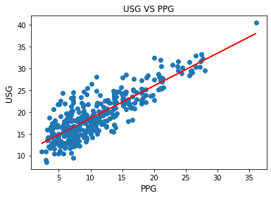

```python
plt.scatter(ppg, USG)
plt.plot(ppg, best_fit[0], c = 'red')
plt.xlabel('PPG', size = 12)
plt.ylabel('USG', size = 12)
plt.title('USG VS PPG')
```

## 3P% vs 3PA

```python
#Clean up data to remove nans
nba_3p = nba.dropna()
```

```python
#Initialize variables
fg3a = np.array(nba_3p['FG3A'])
fg3p = np.array(nba_3p['FG3%'])

w = 0
b = 0
m = len(fg3a)
gamma = 0.001 #random initalization, will need to be adjusted
x = fg3a
y = fg3p
fx = np.zeros(m)
```

```python
wnew = 10 #placeholder vals
bnew = 10
best_fit = ideal_w_b(fx, m, y, gamma, w, b, wnew, bnew, int(1e6), 1e-8)
```

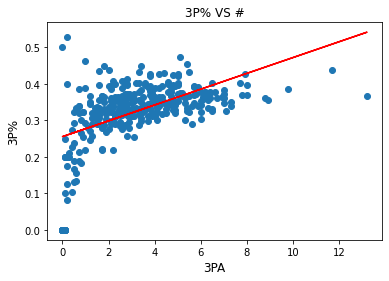

```python
plt.scatter(fg3a, fg3p)
plt.plot(fg3a, best_fit[0], c = 'red')
plt.xlabel('3PA', size = 12)
plt.ylabel('3P%', size = 12)
plt.title('3P% VS #')
```

### Note how the best fit doesn't capture the trend very well at all. This illustrates the need for nonlinear modeling!